# Week 3: Forward Kinematics (DH Convention)

EE0849 Introduction to Robotics

Basri Erdogan

# Part 1: Introduction to Forward Kinematics

## The Forward Kinematics Problem

**Given:** Joint variables $q = [\theta_1, \theta_2, \ldots, \theta_n]^T$

**Find:** End-effector pose (position and orientation)

$$T_{end}^{0} = f(q)$$

This is the **fundamental problem** in robotics!

## Why Forward Kinematics?

- **Simulation:** Where will the robot go if I set these joint angles?
- **Control:** Verify the robot reached the commanded position
- **Path Planning:** Trace out trajectories in Cartesian space
- **Visualization:** Render the robot in 3D

## Serial Manipulators

- Links connected in series (chain)
- Each joint connects two links
- **Base** (Link 0) → **End-Effector** (Link n)

$$T_n^0 = T_1^0 \cdot T_2^1 \cdot T_3^2 \cdots T_n^{n-1}$$

We need a systematic way to find each $T_i^{i-1}$!

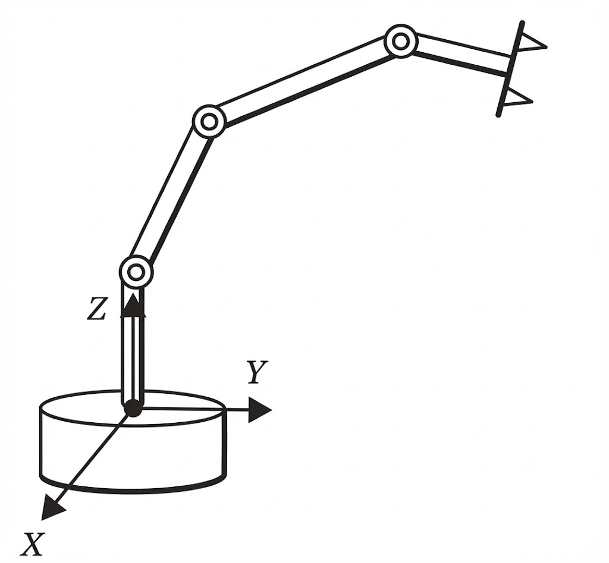

## Joint Types

| Type | Variable | Fixed | Symbol |
| --- | --- | --- | --- |
| **Revolute (R)** | $\theta$ (angle) | $d$ (offset) | ⟳ |
| **Prismatic (P)** | $d$ (displacement) | $\theta$ (angle) | ↕ |

Most industrial robots use only revolute joints (e.g., FANUC: RRRRRR)

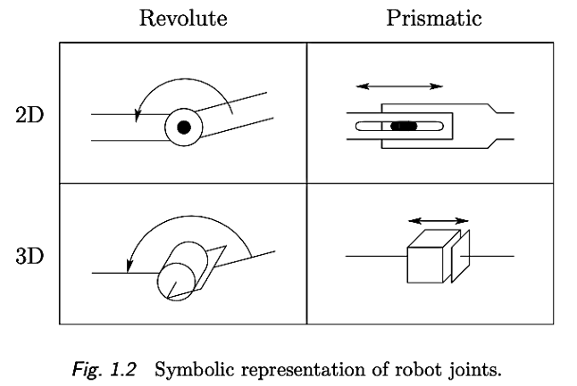

# Part 2: The DH Convention

## Why DH Convention?

- **Jacques Denavit & Richard Hartenberg** (1955)
- Systematic method to assign coordinate frames
- Only **4 parameters** per link (minimal representation)
- Works for ANY serial manipulator

## The Four DH Parameters

| Parameter | Symbol | Description |
| --- | --- | --- |
| **Link Length** | $a_i$ | Distance along $x_i$ from $z_{i-1}$ to $z_i$ |
| **Link Twist** | $\alpha_i$ | Angle about $x_i$ from $z_{i-1}$ to $z_i$ |
| **Link Offset** | $d_i$ | Distance along $z_{i-1}$ from $x_{i-1}$ to $x_i$ |
| **Joint Angle** | $\theta_i$ | Angle about $z_{i-1}$ from $x_{i-1}$ to $x_i$ |

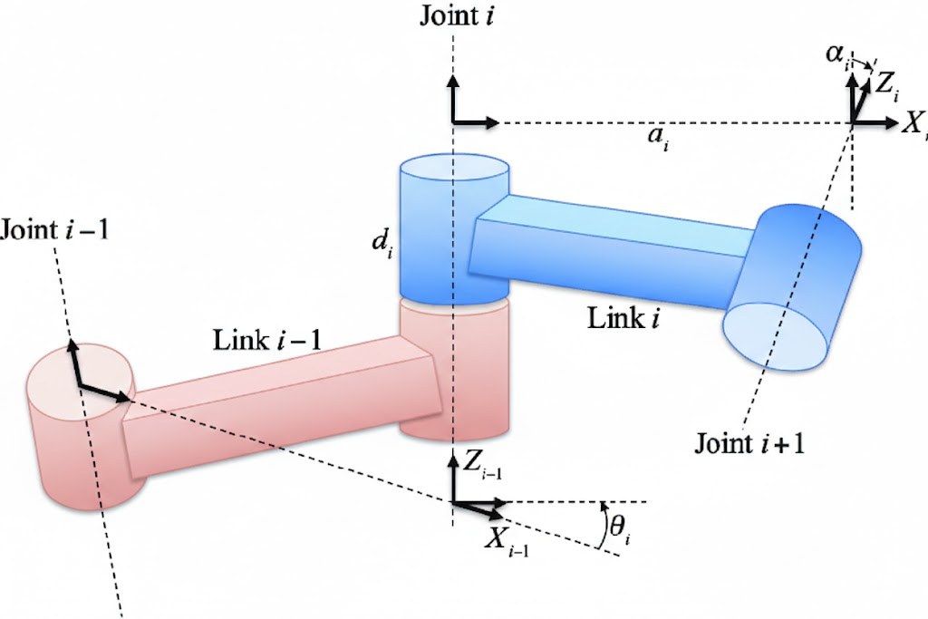

## Visualizing DH Parameters

| Symbol | Definition |
| --- | --- |
| $\theta_i$ | Angle about $z_{i-1}$ from $x_{i-1}$ to $x_i$ |
| $d_i$ | Distance along $z_{i-1}$ from $x_{i-1}$ to $x_i$ |
| $a_i$ | Distance along $x_i$ from $z_{i-1}$ to $z_i$ |
| $\alpha_i$ | Angle about $x_i$ from $z_{i-1}$ to $z_i$ |

[figure not shown]

## The DH Transformation Matrix

Each link transform consists of 4 operations:

$$T_i^{i-1} = R_z(\theta_i) \cdot T_z(d_i) \cdot T_x(a_i) \cdot R_x(\alpha_i)$$

$$= \begin{bmatrix} c_\theta & -s_\theta & 0 & 0 \\ s_\theta & c_\theta & 0 & 0 \\ 0 & 0 & 1 & 0 \\ 0 & 0 & 0 & 1 \end{bmatrix} \begin{bmatrix} 1 & 0 & 0 & 0 \\ 0 & 1 & 0 & 0 \\ 0 & 0 & 1 & d \\ 0 & 0 & 0 & 1 \end{bmatrix} \begin{bmatrix} 1 & 0 & 0 & a \\ 0 & 1 & 0 & 0 \\ 0 & 0 & 1 & 0 \\ 0 & 0 & 0 & 1 \end{bmatrix} \begin{bmatrix} 1 & 0 & 0 & 0 \\ 0 & c_\alpha & -s_\alpha & 0 \\ 0 & s_\alpha & c_\alpha & 0 \\ 0 & 0 & 0 & 1 \end{bmatrix}$$

1. $R_z(\theta_i)$: Rotate about $z_{i-1}$ by $\theta_i$
2. $T_z(d_i)$: Translate along $z_{i-1}$ by $d_i$
3. $T_x(a_i)$: Translate along $x_i$ by $a_i$
4. $R_x(\alpha_i)$: Rotate about $x_i$ by $\alpha_i$

## DH Matrix (Expanded Form)

$$T_i^{i-1} = \begin{bmatrix}
c_{\theta_i} & -s_{\theta_i}c_{\alpha_i} & s_{\theta_i}s_{\alpha_i} & a_i c_{\theta_i} \\
s_{\theta_i} & c_{\theta_i}c_{\alpha_i} & -c_{\theta_i}s_{\alpha_i} & a_i s_{\theta_i} \\
0 & s_{\alpha_i} & c_{\alpha_i} & d_i \\
0 & 0 & 0 & 1
\end{bmatrix}$$

Where $c_{\theta} = \cos\theta$, $s_{\theta} = \sin\theta$, etc.

**Memorize this matrix!** (or know how to derive it)

## Conceptual Check 1

**Question:** For a revolute joint, which DH parameter is the joint variable?

**Answer:** $\theta_i$ is the variable, $d_i$ is fixed (constant).

For a prismatic joint, it’s reversed: $d_i$ is variable, $\theta_i$ is fixed.

# Part 3: Frame Assignment Rules

## Frame Assignment: The Key Idea

Each DH frame is fully determined by two axes: **$z_i$** and **$x_i$**.

| Axis | How to assign |
| --- | --- |
| $z_i$ | Along the axis of joint $i+1$ |
| $x_i$ | Along the **common normal** from $z_{i-1}$ to $z_i$ |
| $y_i$ | Completes the right-hand rule |

The **common normal** is the shortest line perpendicular to both $z_{i-1}$ and $z_i$.

## Frame Assignment: Procedure

1. Label all joint axes $z_0, z_1, \ldots, z_{n-1}$
2. For each frame $i$, find the common normal between $z_{i-1}$ and $z_i$
3. Place the origin $O_i$ where the common normal meets $z_i$
4. Point $x_i$ along the common normal (from $z_{i-1}$ toward $z_i$)
5. $y_i = z_i \times x_i$

## Special Cases

**Intersecting axes** (e.g., spherical wrist):

- Common normal has zero length → $a_i = 0$
- Choose $x_i$ along $z_{i-1} \times z_i$

**Parallel axes** (e.g., planar robots):

- Infinitely many common normals → origin placement is free
- Convention: choose $O_i$ to make $d_i = 0$

## Base and End-Effector Frames

**Frame 0** (base):

- $z_0$ along the first joint axis
- $x_0$ is a free choice (often pointing “forward”)

**Frame $n$** (end-effector):

- Attached to the last link at the tool center point (TCP)
- May need an additional fixed transform $T_{tool}$

# Part 4: 2-Link Planar Arm

## The Simplest Manipulator

[figure not shown]

2-Link Planar Robot

- 2 revolute joints, both axes parallel (pointing out of page: $z$)
- Motion in the x-y plane only

## Frame Assignment: 2-Link Planar

[figure not shown]

2-Link Robot Configurations

All $z$ axes point **out of the page** (parallel)

## DH Table: 2-Link Planar

| Link $i$ | $\theta_i$ | $d_i$ | $a_i$ | $\alpha_i$ |
| --- | --- | --- | --- | --- |
| 1 | $\theta_1$ | 0 | $L_1$ | 0 |
| 2 | $\theta_2$ | 0 | $L_2$ | 0 |

- $\theta_1, \theta_2$ are joint variables
- $d = 0$ (planar, no offset)
- $\alpha = 0$ (parallel axes)

[figure not shown]

## Worked Example 1: 2-Link FK

**Step 1:** $T_1^0$ (with $\alpha_1=0$, $d_1=0$)

$$T_1^0 = \begin{bmatrix} c_1 & -s_1 & 0 & L_1 c_1 \\ s_1 & c_1 & 0 & L_1 s_1 \\ 0 & 0 & 1 & 0 \\ 0 & 0 & 0 & 1 \end{bmatrix}$$

**Step 2:** $T_2^1$

$$T_2^1 = \begin{bmatrix} c_2 & -s_2 & 0 & L_2 c_2 \\ s_2 & c_2 & 0 & L_2 s_2 \\ 0 & 0 & 1 & 0 \\ 0 & 0 & 0 & 1 \end{bmatrix}$$

**Step 3:** $T_2^0 = T_1^0 \cdot T_2^1$

$$T_2^0 = \begin{bmatrix} c_{12} & -s_{12} & 0 & L_1 c_1 + L_2 c_{12} \\ s_{12} & c_{12} & 0 & L_1 s_1 + L_2 s_{12} \\ 0 & 0 & 1 & 0 \\ 0 & 0 & 0 & 1 \end{bmatrix}$$

where $c_{12} = \cos(\theta_1 + \theta_2)$, $s_{12} = \sin(\theta_1 + \theta_2)$

These come from $R_z(\theta_1) \cdot R_z(\theta_2)$: multiplying the rotation blocks uses the trig identity $\cos(a+b) = \cos a \cos b - \sin a \sin b$.

**End-Effector Position:**

$$x = L_1 \cos\theta_1 + L_2 \cos(\theta_1 + \theta_2)$$
$$y = L_1 \sin\theta_1 + L_2 \sin(\theta_1 + \theta_2)$$

## Practice Problem 1

**Given:** 2-link planar arm with $L_1 = 1$ m, $L_2 = 0.5$ m. **Find** $(x, y)$ for each case:

**Case 1:** $\theta_1 = 0°$, $\theta_2 = 0°$

$x = 1 \cdot \cos(0) + 0.5 \cdot \cos(0)$ $\quad = 1.5$ m

$y = 1 \cdot \sin(0) + 0.5 \cdot \sin(0)$ $\quad = 0$ m

**Case 2:** $\theta_1 = 90°$, $\theta_2 = 0°$

$x = 1 \cdot \cos(90°) + 0.5 \cdot \cos(90°)$ $\quad = 0$ m

$y = 1 \cdot \sin(90°) + 0.5 \cdot \sin(90°)$ $\quad = 1.5$ m

**Case 3:** $\theta_1 = 45°$, $\theta_2 = 45°$

$x = 1 \cdot \cos(45°) + 0.5 \cdot \cos(90°)$ $\quad = 0.707$ m

$y = 1 \cdot \sin(45°) + 0.5 \cdot \sin(90°)$ $\quad = 1.207$ m

[figure not shown]

# Part 5: 3-Link Spatial Arm (RRR)

## Adding a Third Dimension

What if axes are **not** parallel?

[figure not shown]

3-Link Spatial Robot

## 3-Link Arm: Home Position

Home configuration ($\theta_1 = \theta_2 = \theta_3 = 0$) for deriving DH parameters:

[figure not shown]

3-Link Robot Home Position

## DH Table: 3-Link Anthropomorphic Arm

| Link | $\theta_i$ | $d_i$ | $a_i$ | $\alpha_i$ |
| --- | --- | --- | --- | --- |
| 1 | $\theta_1$ | $d_1$ | 0 | $90°$ |
| 2 | $\theta_2$ | 0 | $a_2$ | 0 |
| 3 | $\theta_3$ | 0 | $a_3$ | 0 |

- Joint 1: Waist rotation (vertical $z_0$)
- Joint 2: Shoulder (horizontal $z_1$)
- Joint 3: Elbow (horizontal $z_2$, parallel to $z_1$)

## Worked Example 2: 3-Link Transforms

**Link 1:** $\theta_1$, $d_1$, $a_1=0$, $\alpha_1=90°$

$$T_1^0 = \begin{bmatrix} c_1 & 0 & s_1 & 0 \\ s_1 & 0 & -c_1 & 0 \\ 0 & 1 & 0 & d_1 \\ 0 & 0 & 0 & 1 \end{bmatrix}$$

Note: $\cos(90°) = 0$, $\sin(90°) = 1$

**Link 2:** $\theta_2$, $d_2=0$, $a_2$, $\alpha_2=0$

$$T_2^1 = \begin{bmatrix} c_2 & -s_2 & 0 & a_2 c_2 \\ s_2 & c_2 & 0 & a_2 s_2 \\ 0 & 0 & 1 & 0 \\ 0 & 0 & 0 & 1 \end{bmatrix}$$

Same form as planar case (since $\alpha = 0$)

# Part 6: Industrial Robots (FANUC)

## 6-DOF Industrial Manipulator

Most industrial robots have 6 joints:

- **Joints 1-3:** Position the wrist (arm)
- **Joints 4-6:** Orient the end-effector (wrist)

This provides **6 DOF** = 3 position + 3 orientation

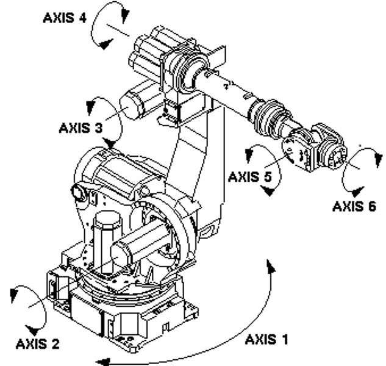

## Spherical Wrist

Joints 4, 5, 6 axes intersect at a single point:

[figure not shown]

Spherical Wrist

This allows **decoupling** of position and orientation!

## FANUC Robot Example

| Joint | Type | Range |
| --- | --- | --- |
| J1 | Revolute | ±170° |
| J2 | Revolute | ±120° |
| J3 | Revolute | ±135° |
| J4 | Revolute | ±200° |
| J5 | Revolute | ±135° |
| J6 | Revolute | ±360° |

## FANUC DH Parameters

| Link | $\theta$ | $d$ (mm) | $a$ (mm) | $\alpha$ |
| --- | --- | --- | --- | --- |
| 1 | $\theta_1$ | 330 | 50 | $-90°$ |
| 2 | $\theta_2$ | 0 | 330 | $0°$ |
| 3 | $\theta_3$ | 0 | 35 | $-90°$ |
| 4 | $\theta_4$ | 335 | 0 | $90°$ |
| 5 | $\theta_5$ | 0 | 0 | $-90°$ |
| 6 | $\theta_6$ | 80 | 0 | $0°$ |

## FANUC Robot Visualization

[figure not shown]

Schematic (DH frames)

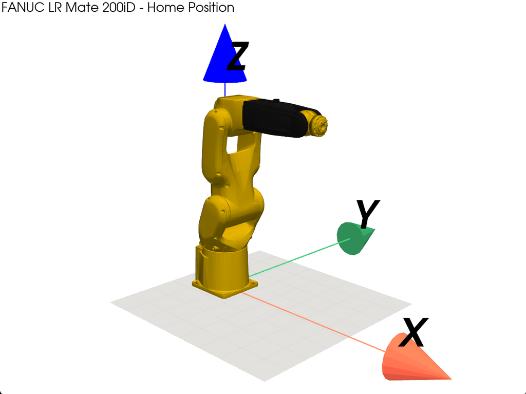

3D Model (URDF + STL meshes)

## Conceptual Check 2

**Question:** Why do most industrial robots have exactly 6 joints?

**Answer:** 6 DOF provides:

- 3 DOF for position (x, y, z)
- 3 DOF for orientation (roll, pitch, yaw)

This allows reaching any pose in 3D space (within workspace).

# Part 7: Summary

## Key Takeaways

1. **Forward Kinematics:** $T_n^0 = f(q)$ - joint angles to end-effector pose
2. **DH Convention:** 4 parameters per link ($\theta, d, a, \alpha$)
3. **DH Matrix:**
   $$T_i^{i-1} = \begin{bmatrix}
   c_\theta & -s_\theta c_\alpha & s_\theta s_\alpha & a \cdot c_\theta \\
   s_\theta & c_\theta c_\alpha & -c_\theta s_\alpha & a \cdot s_\theta \\
   0 & s_\alpha & c_\alpha & d \\
   0 & 0 & 0 & 1
   \end{bmatrix}$$
4. **Python tools:** `roboticstoolbox` (`DHRobot`, `RevoluteDH`, `fkine()`) — see Lab 2 notebook

## Common Mistakes

| Mistake | Correct |
| --- | --- |
| Wrong $\alpha$ sign | Follow right-hand rule for rotation |
| Degrees vs radians | Python uses **radians**! |
| $z$ axis wrong | $z_i$ along joint $i+1$ axis |
| Forgetting base frame | Frame 0 is at robot base |

## DH Convention Variants

**Warning:** There are TWO common DH conventions!

|  | Standard DH | Modified DH (Craig) |
| --- | --- | --- |
| Order | $R_z T_z T_x R_x$ | $R_x T_x R_z T_z$ |
| Frame location | On distal end | On proximal end |
| Used in | Spong textbook | Craig textbook |

**This course uses Standard DH convention!**

## Reading Assignment

- **Spong, Chapter 3.1 - 3.3:** Forward Kinematics, DH Convention

## Lab Preview

- **Lab 2:** Building the Virtual FANUC
- Extract DH parameters from datasheet
- Build `DHRobot` model in Python
- Verify dimensions match

## Exit Ticket

**Create the DH table** for this 2-joint robot:

[figure not shown]

- Joint 1 rotates about **vertical** $z_0$
- Link rises $d_1 = 0.5$ m, then turns horizontal
- Joint 2 rotates about **horizontal** $z_1$
- Link extends $a_2 = 0.3$ m

**Hint:** $z_0$ is vertical, $z_1$ is horizontal.

What is $\alpha_1$?

## Exit Ticket: Solution

| Link | $\theta$ | $d$ | $a$ | $\alpha$ |
| --- | --- | --- | --- | --- |
| 1 | $\theta_1$ | 0.5 | 0 | $90°$ |
| 2 | $\theta_2$ | 0 | 0.3 | 0 |

Key insight: $\alpha_1 = 90°$ because $z_0$ (vertical) is perpendicular to $z_1$ (horizontal)

## Next Week

- **Inverse Kinematics**
- Geometric solutions
- Multiple solutions (elbow up/down)
- FANUC configuration strings

## Questions?

Contact: b.erdogan@iku.edu.tr